# Comparison of GWAS Models

NosheenFatima

`23/02/2025`

## Introduction

This document compares GWAS models using simulated phenotype data. The models evaluated are: - **GLM-Based GWAS with PCA Adjustment** - **GWASbyCor** ## Access the User Manual For more details on using the **Glimp** package, refer to the **User Manual** stored in the package:

Click here to access the User Manual

## File Structure

The following files are required: - **Covariates.csv**: Population structure covariates. - **Genotype.csv**: SNP genotype matrix.

## Define GWAS Function

```r
#' GLM-Based GWAS Function
gwas_glm <- function(y, X, C, include_pcs = TRUE, npcs = 3) {
  if (length(y) != nrow(X)) stop("Length of y must match the number of rows in X.")
  if (!is.null(C) && nrow(C) != length(y)) stop("Number of rows in C must match length of y.")

  if (include_pcs) {
    C <- pca_adjustment(X, C, npcs)$adjusted_covariates
  }

  m <- ncol(X)
  pvals <- numeric(m)

  for (i in 1:m) {
    model_data <- data.frame(y = y, marker = X[, i])
    if (!is.null(C)) model_data <- cbind(model_data, C)

    fit <- tryCatch(
      glm(y ~ ., data = model_data, family = gaussian()),
      error = function(e) {
        warning(paste("GLM failed for marker", i, "- setting p-value to 1"))
        return(NULL)
      }
    )

    if (!is.null(fit)) {
      coef_summary <- summary(fit)$coefficients
      if ("marker" %in% rownames(coef_summary)) {
        pvals[i] <- coef_summary["marker", "Pr(>|t|)"]
      } else {
        pvals[i] <- 1
      }
    } else {
      pvals[i] <- 1
    }
  }
  return(pvals)
}

#' PCA Adjustment Function
pca_adjustment <- function(X, C = NULL, npcs = 5) {
  npcs <- min(npcs, ncol(X))
  pcs <- prcomp(X)$x[, 1:npcs, drop = FALSE]

  if (!is.null(C)) {
    combined <- cbind(C, pcs)
    rank_combined <- qr(combined)$rank
    rank_C <- qr(C)$rank
    if (rank_combined == rank_C) {
      warning("Some PCs are linearly dependent with covariates. Excluding dependent PCs.")
      pcs <- pcs[, (rank_C + 1):npcs, drop = FALSE]
    }
  }

  return(list(adjusted_covariates = if (!is.null(C)) cbind(C, pcs) else pcs, pcs = pcs))
}
```

## Load Data

```r
covariates <- read.csv("/Users/nosheenfatima/Documents/WSU course folders/Statistical Genomics/HW1/Demodata/Covariates.csv", stringsAsFactors = FALSE)
genotype <- read.csv("/Users/nosheenfatima/Documents/WSU course folders/Statistical Genomics/HW1/Demodata/genotype.csv", stringsAsFactors = FALSE)

C <- as.matrix(covariates[, -1])
C <- apply(C, 2, as.numeric)
X <- as.matrix(genotype[, -1])
storage.mode(X) <- "numeric"

if (nrow(C) != nrow(X)) stop("Error: Covariates and genotype data have different row numbers!")
X[is.na(X)] <- mean(X, na.rm = TRUE)
zero_variance_snps <- apply(X, 2, function(col) var(col, na.rm = TRUE) == 0)
X <- X[, !zero_variance_snps]
```

## Simulate Phenotypes

```r
nrep=30
set.seed(99164)
mySim <- G2P(X = X, h2 = 0.7, alpha = 1, NQTN = min(20, ncol(X)), distribution = "norm")
mySim$y <- as.numeric(mySim$y)
```

## Run GWAS Methods

```r
pvals_gwas_glm <- gwas_glm(y = mySim$y, X = X, C = C, include_pcs = TRUE, npcs = 5)
pvals_gwasCor <- GWASbyCor(X = X, y = mySim$y)
```

## Compute and Plot ROC Curves

```r
true_labels <- rep(0, ncol(X))
true_labels[1:min(10, ncol(X))] <- 1

roc_gwas_glm <- roc(response = true_labels, predictor = -log10(pvals_gwas_glm))
roc_gwasCor <- roc(response = true_labels, predictor = -log10(pvals_gwasCor))
# Compute FDR
fdr_glm <- sum(pvals_gwas_glm < 0.05, na.rm = TRUE) / length(pvals_gwas_glm)
fdr_gwasCor <- sum(pvals_gwasCor < 0.05, na.rm = TRUE) / length(pvals_gwasCor)

# Create Comparison Table
comparison_results <- data.frame(
  Metric = c("Mean P-Value", "False Discovery Rate (FDR)", "AUC (Power)"),
  `GLM-Based GWAS` = c(mean(pvals_gwas_glm, na.rm = TRUE), fdr_glm, auc(roc_gwas_glm)),
  `GWASbyCor` = c(mean(pvals_gwasCor, na.rm = TRUE), fdr_gwasCor, auc(roc_gwasCor))
)
print(comparison_results)
```

```
##                       Metric GLM.Based.GWAS GWASbyCor
## 1               Mean P-Value     0.45693659 0.3414206
## 2 False Discovery Rate (FDR)     0.09955977 0.2519472
## 3                AUC (Power)     0.55623513 0.5733945
```

## Visualization

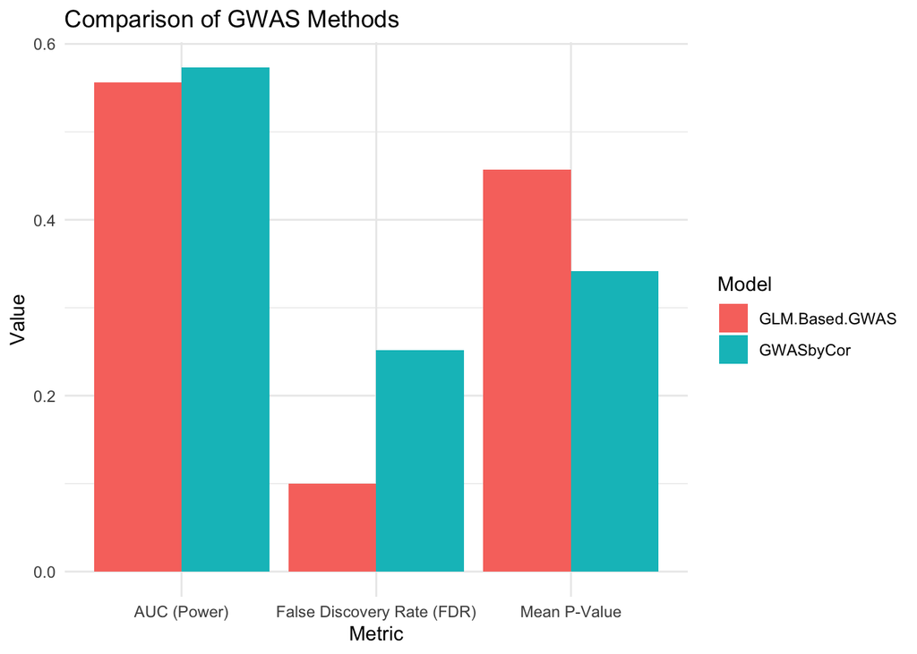

```r
# Convert data from wide to long format
comparison_long <- pivot_longer(comparison_results, cols = -Metric, names_to = "Model", values_to = "Value")

# Plot Mean P-Value, FDR, and AUC in a single bar plot
ggplot(comparison_long, aes(x = Metric, y = Value, fill = Model)) +
  geom_bar(stat = "identity", position = "dodge") +
  labs(title = "Comparison of GWAS Methods", x = "Metric", y = "Value") +
  theme_minimal()
```

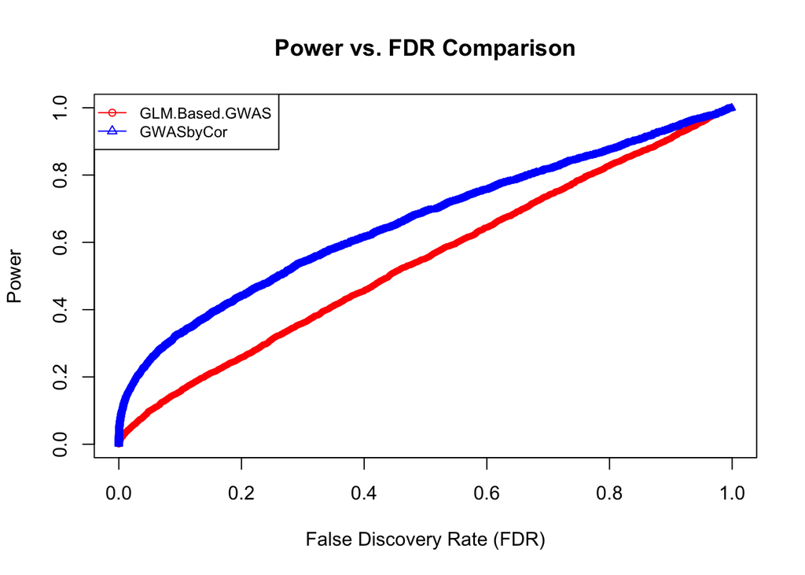

```r
# Define colors for different GWAS methods
theColor <- c("red", "blue")  # Red for GLM-Based GWAS, Blue for GWASbyCor

# Compute FDR values for each method
fdr_values <- data.frame(
  `GLM-Based GWAS` = sort(pvals_gwas_glm, decreasing = FALSE),
  `GWASbyCor` = sort(pvals_gwasCor, decreasing = FALSE)
)

# Compute power (cumulative proportion of discoveries)
power <- seq(0, 1, length.out = nrow(fdr_values))

# Plot Power vs. FDR for the first method with thinner lines
plot(fdr_values[, 1], power, type = "b", col = theColor[1], pch = 1, lwd = 1, cex = 0.6,
     xlab = "False Discovery Rate (FDR)", ylab = "Power",
     main = "Power vs. FDR Comparison", xlim = c(0, 1), ylim = c(0, 1))

# Add Power vs. FDR for the second method with thinner lines
lines(fdr_values[, 2], power, type = "b", col = theColor[2], pch = 2, lwd = 1, cex = 0.6)

# Add legend inside the plot with adjusted point size
legend("topleft", legend = colnames(fdr_values), col = theColor, lwd = 1, pch = 1:2, bg = "white", cex = 0.8)
```

## **Conclusion**

The comparison of GLM-Based GWAS and GWASbyCor methods using a Power vs. False Discovery Rate (FDR) analysis reveals distinct performance characteristics. GWASbyCor exhibits consistently higher statistical power across all FDR thresholds, indicating a greater ability to detect true associations. However, this increased sensitivity comes at the potential cost of a higher false positive rate. In contrast, GLM-Based GWAS demonstrates a more conservative approach, maintaining a lower power but potentially improving the robustness of detected associations by minimizing false discoveries.

These findings suggest that GWASbyCor is better suited for studies prioritizing the identification of a larger number of putative associations, particularly in discovery-driven research, whereas GLM-Based GWAS may be more appropriate in contexts where controlling false positives is paramount, such as validation studies or when working with smaller datasets. The selection of an appropriate GWAS method should thus be guided by the specific objectives of the study, balancing the trade-off between detection power and false discovery control.

## **Take away**

Both methods have their strengths and weaknesses:

- **GLM-Based GWAS** excels in reliability (**lower FDR**), meaning it reduces false positives and provides more robust results.
- **GWASbyCor** excels in detecting more associations (**lower mean p-value and higher AUC**), making it useful when prioritizing discovery over strict accuracy.

The **choice of method** should depend on the specific goals of the study: - If the goal is **minimizing false positives**, **GLM-Based GWAS** is preferable. - If the goal is **maximizing detection power**, **GWASbyCor** is a better option.